# **IMPORTING THE DATASET AND CONVERSION TO DATAFRAME**

# **ANALYSIS USING GRAPHS AND TESTS**

# Helps in better visualization of his career

# TOTAL MATCHES PLAYED AGAINST EVERY TEAM

```python
newdata1=VKdata['Opposition'].value_counts()#Unique values will be considered and frequency is assessed and it creates a dataframe
```

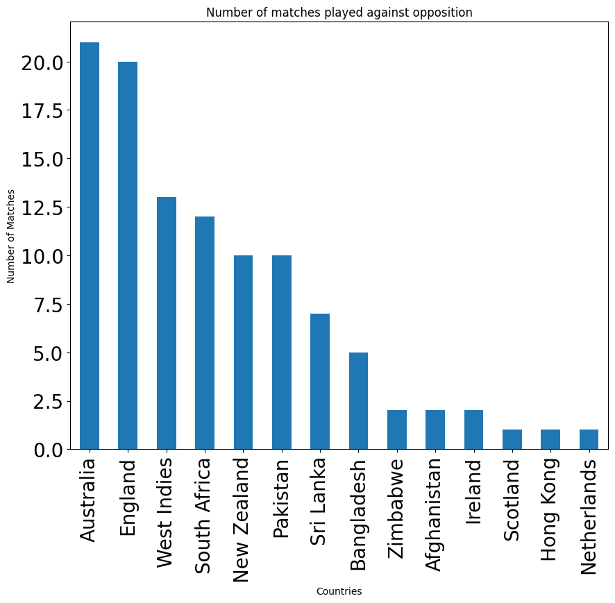

```python
newdata=VKdata['Opposition'].value_counts().plot(kind='bar',title='Number of matches played against opposition',figsize=(10,8))#Here VKdata['Opposition'].value_counts() is a new dataframe and we consider this dataframe to do the plot width=10, height=5
newdata.set_xlabel('Countries',fontsize=10)
newdata.set_ylabel('Number of Matches',fontsize=10)
newdata.tick_params(axis='x', labelsize=20)
newdata.tick_params(axis='y',labelsize=20)
```

```python
newdata1
```

```
Australia       21
England         20
West Indies     13
South Africa    12
New Zealand     10
Pakistan        10
Sri Lanka        7
Bangladesh       5
Zimbabwe         2
Afghanistan      2
Ireland          2
Scotland         1
Hong Kong        1
Netherlands      1
Name: Opposition, dtype: int64
```

We can infer from the above that Kohli has played the most number of matches in his career against Australia.

# INNINGS PLAYED PER YEAR

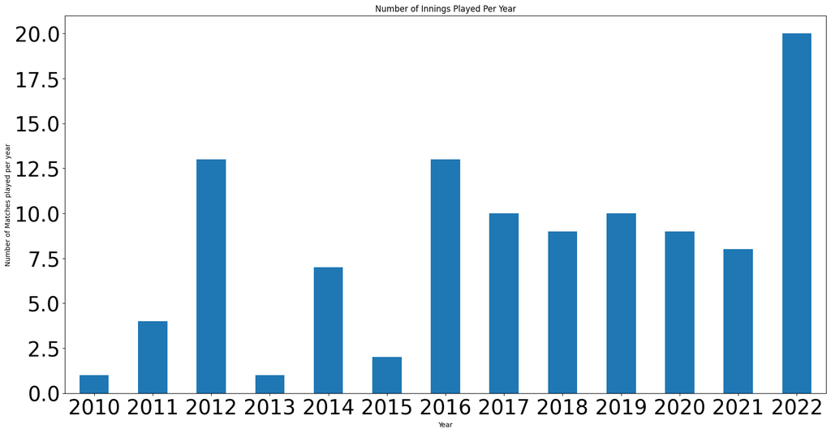

```python
VKdata['year'].value_counts().sort_index().plot(kind='bar',title='Number of Innings Played Per Year',figsize=(20,10))
VKdata['year'].value_counts().sort_index().plot().tick_params(axis='x', labelsize=30)
VKdata['year'].value_counts().sort_index().plot().tick_params(axis='y', labelsize=30)
VKdata['year'].value_counts().sort_index().plot().set_xlabel('Year',fontsize=10)
VKdata['year'].value_counts().sort_index().plot().set_ylabel('Number of Matches played per year',fontsize=10)
```

We can infer from the above that till now he has played the most number of innings in the year 2022.

# NUMBER OF RUNS SCORED PER YEAR

```python
a=VKdata.groupby('year')#Groups all the data by the year attribute
```

```python
a.first()#Gives the first value of every grouping
```

| year | Runs | Balls | Fours | Sixes | SR | Opposition | Ground | Match Date | Notout |
| --- | --- | --- | --- | --- | --- | --- | --- | --- | --- |
| 2010 | 26 | 21 | 3 | 1 | 123 | Zimbabwe | Harare | 2010-06-12 | 1 |
| 2011 | 28 | 19 | 5 | 0 | 147 | South Africa | Durban | 2011-01-09 | 0 |
| 2012 | 22 | 21 | 0 | 1 | 104 | Australia | Sydney | 2012-02-01 | 0 |
| 2013 | 29 | 22 | 2 | 1 | 131 | Australia | Rajkot | 2013-10-10 | 0 |
| 2014 | 36 | 32 | 4 | 1 | 112 | Pakistan | Mirpur | 2014-03-21 | 1 |
| 2015 | 43 | 27 | 1 | 3 | 159 | South Africa | Dharamsala | 2015-10-02 | 0 |
| 2016 | 90 | 55 | 9 | 2 | 163 | Australia | Adelaide | 2016-01-26 | 1 |
| 2017 | 29 | 26 | 4 | 0 | 111 | England | Kanpur | 2017-01-26 | 0 |
| 2018 | 26 | 20 | 2 | 1 | 130 | South Africa | Johannesburg | 2018-02-18 | 0 |
| 2019 | 24 | 17 | 3 | 0 | 141 | Australia | Visakhapatnam | 2019-02-24 | 0 |
| 2020 | 30 | 17 | 1 | 2 | 176 | Sri Lanka | Indore | 2020-01-07 | 1 |
| 2021 | 0 | 5 | 0 | 0 | 0 | England | Ahmedabad | 2021-03-12 | 0 |
| 2022 | 17 | 13 | 1 | 0 | 130 | West Indies | Eden Gardens | 2022-02-16 | 0 |

[figure not shown]

```python
a['Runs'].sum().plot(kind='bar',title='Number of runs per year',figsize=(20,8))
a['Runs'].sum().plot().tick_params(axis='x',labelsize=20)
a['Runs'].sum().plot().tick_params(axis='y',labelsize=20)
a['Runs'].sum().plot().set_xlabel('Year',fontsize=10)
a['Runs'].sum().plot().set_ylabel('Number of Runs',fontsize=10)
```

```python
total_runs_scored_per_year=a['Runs'].sum()
```

```python
total_runs_scored_per_year
```

```
year
2010     26
2011     61
2012    471
2013     29
2014    385
2015     44
2016    641
2017    299
2018    211
2019    466
2020    295
2021    299
2022    781
Name: Runs, dtype: int64
```

By the Graph and The Above values, we can conclude that till now 2022 is the year in which Kohli has scored the maximum number of runs

## NUMBER OF RUNS SCORED AGAINST EACH OPPOSITION

```python
b=VKdata.groupby('Opposition')
```

```python
b.first()
```

| Opposition | Runs | Balls | Fours | Sixes | SR | Ground | Match Date | Notout | year |
| --- | --- | --- | --- | --- | --- | --- | --- | --- | --- |
| Afghanistan | 50 | 39 | 4 | 2 | 128 | Colombo(RPS) | 2012-09-19 | 0 | 2012 |
| Australia | 22 | 21 | 0 | 1 | 104 | Sydney | 2012-02-01 | 0 | 2012 |
| Bangladesh | 57 | 50 | 3 | 1 | 114 | Mirpur | 2014-03-28 | 1 | 2014 |
| England | 4 | 5 | 0 | 0 | 80 | Manchester | 2011-08-31 | 0 | 2011 |
| Hong Kong | 59 | 44 | 1 | 3 | 134 | Dubai(DSC) | 2022-08-31 | 1 | 2022 |
| Ireland | 0 | 2 | 0 | 0 | 0 | Dublin (Malahide) | 2018-06-27 | 0 | 2018 |
| Netherlands | 62 | 44 | 3 | 2 | 140 | Sydney | 2022-10-27 | 1 | 2022 |
| New Zealand | 70 | 41 | 10 | 1 | 170 | Chennai | 2012-09-11 | 0 | 2012 |
| Pakistan | 78 | 61 | 8 | 2 | 127 | Colombo(RPS) | 2012-09-30 | 1 | 2012 |
| Scotland | 2 | 2 | 0 | 0 | 100 | Dubai(DSC) | 2021-11-05 | 1 | 2021 |
| South Africa | 28 | 19 | 5 | 0 | 147 | Durban | 2011-01-09 | 0 | 2011 |
| Sri Lanka | 68 | 48 | 11 | 1 | 141 | Pallekele | 2012-08-07 | 0 | 2012 |
| West Indies | 14 | 12 | 2 | 0 | 116 | Port of Spain | 2011-06-04 | 0 | 2011 |
| Zimbabwe | 26 | 21 | 3 | 1 | 123 | Harare | 2010-06-12 | 1 | 2010 |

[figure not shown]

```python
b['Runs'].sum().plot(kind='bar',title='Number of Runs against each Opposition',figsize=(60,10))
b['Runs'].sum().plot().tick_params(axis='x',labelsize=35)
b['Runs'].sum().plot().tick_params(axis='y',labelsize=35)
b['Runs'].sum().plot().set_xlabel('Countries',fontsize=10)
b['Runs'].sum().plot().set_ylabel('Runs',fontsize=10)
```

```python
b['Runs'].sum()
```

```
Opposition
Afghanistan     172
Australia       794
Bangladesh      193
England         639
Hong Kong        59
Ireland           9
Netherlands      62
New Zealand     311
Pakistan        488
Scotland          2
South Africa    318
Sri Lanka       339
West Indies     570
Zimbabwe         52
Name: Runs, dtype: int64
```

We can conclude that Virat Kohli has scored the maximum number of runs against Australia.